# The effects of housing rehabilitation policies on residential mobility preferences in Andalusia

28-06-2023

## 1. Introduction

This project is an examination of the RUCOSA survey made by The Urban Governance Lab in Andalusia to evaluate the effects of EU urban policies on vulnerable neighbourhoods

Its main hypothesis are the following:

$H_1$: The citizens in rehabilitated households have less propensity to leave neighbourhood (Individiual effect)

$H_2$: The citizens in the affected areas have less propensity to leave the neighbourhood, even if they have not been directly affected by these policies.

## 2. Data loading and cleaning

### 2.1. Packages and dataset

```r
## necessary packages

library(tidyverse)
library(readr)
library(sem)
library(randomForest)
library(lmtest)
library(AER)
library(lavaan)
library(cowplot)
library(semPlot)
library(vtable)
library(ggdag)
library(dagitty)

# Save the dataset in "Downloads" directory in order to open it

USUARIO <- Sys.getenv("USERNAME")

df <- read_delim(paste0("C:/Users/",USUARIO,"/Downloads/RCS_PT3_270223_Indexes.csv"), delim = ";", escape_double = TRUE, trim_ws = TRUE)
```

### 2.2. Cleaning

```r
# Years living in the neighbourhood

df$P0109 <- ifelse(df$P0109 == 98, df$C02, df$P0109)

df$P0109 <- ifelse(df$P0109 > 90, NA, df$P0109)
# deal with NA

df[, !(names(df) %in% c("P0109"))] <- lapply(df[, !(names(df) %in% c("P0109"))], function(x) ifelse(x > 76, NA, x))

# Estimating NA for more than 30% missing is not considered:

df <- df[colSums(is.na(df))/nrow(df) < .30]

# character and numeric to factor

df <- df %>% mutate_if(is.character, as.factor)


df$TIPO_ZONA <- cut(df$TIPO_ZONA, breaks = c(0, 1, 2, 3), labels = c("Experimental", "Control", "Other"))

# Eliminate control variable:

df <- df[df$TIPO_ZONA != 'Other', ]

df <- df %>%
  mutate(exp = ifelse(TIPO_ZONA == "Experimental", 1, 0))

# eliminate  variables with unique values

df <- select(df, -one_of(names(df)[sapply(df, function(x) n_distinct(x) == nrow(df))]))


sum(is.na(df$P0102_C))/length(df$P0102_C)

# median and mode AND other na impute
df <- na.roughfix(df)


df$P0209[df$P0209 > 1] <- 0
df$P0214[df$P0214 == 2] <- 0
df$P0219[df$P0219 == 2] <- 0


# building "social support" variable
df <- df %>% mutate(apoyo = log((P0905_A + P0905_B + P0905_C + P0905_D + P0905_E) / 5))

# for log(0)
df$apoyo[df$apoyo == -Inf] <- min(df$apoyo[is.finite(df$apoyo)])

# building "housing problems" variable:


df$P1009_A[df$P1009_A == 2] <- 0
df$P1009_B[df$P1009_B == 2] <- 0
df$P1009_C[df$P1009_C == 2] <- 0
df$P1009_G[df$P1009_G == 2] <- 0

df <- df %>% mutate(problemviv = (P1009_A + P1009_B + P1009_C + P1009_G) / 4)

# building "participation" variable (considered but not included)

var_names <- paste0("P0401_", LETTERS[1:10])

# Loop through the variable names and replace values
for (var_name in var_names) {
  df[[var_name]][df[[var_name]] < 4] <- 1
  df[[var_name]][df[[var_name]] == 4] <- 0
}

df <-  df %>% mutate(relvel= (P0401_A + P0401_B + P0401_C + P0401_D + P0401_E + P0401_F + P0401_G + P0401_H + P0401_I + P0401_J) / 10)

# building "increase in housing satisfaction variable"
df = df %>% mutate(diffviv =(P0224 - P0225))

# categories of families
df$P0902 <- cut(df$P0902,
                breaks = c(-Inf, 1, 2, 3, 4, 5, 6, 7, 8),
                labels = c("Couple with children",
                           "Couple without children",
                           "Mother with children",
                           "Father with Children",
                           "Alone woman",
                           "Alone man",
                           "Several families",
                           "Other"))
```

### 2.3. Variables:

**Independent**:

hsn: Home has been rehabilitated

bld: building has been rehabilitated

env: environment has been rehabilitated

**Level**:

**Dependent variables and mechanisms**:

stng: satisfaction with the neighbourhood

resmov: propensity for residential mobility

**Covariables**:

eco: perceived income (1-10)

family: kind of family

age: years living in the neighbourhood

apoyo: social support index (log)

relvel: participation in social activities in the neighbourhood

problemviv: housing problems index

### 2.3. Descriptive graphs

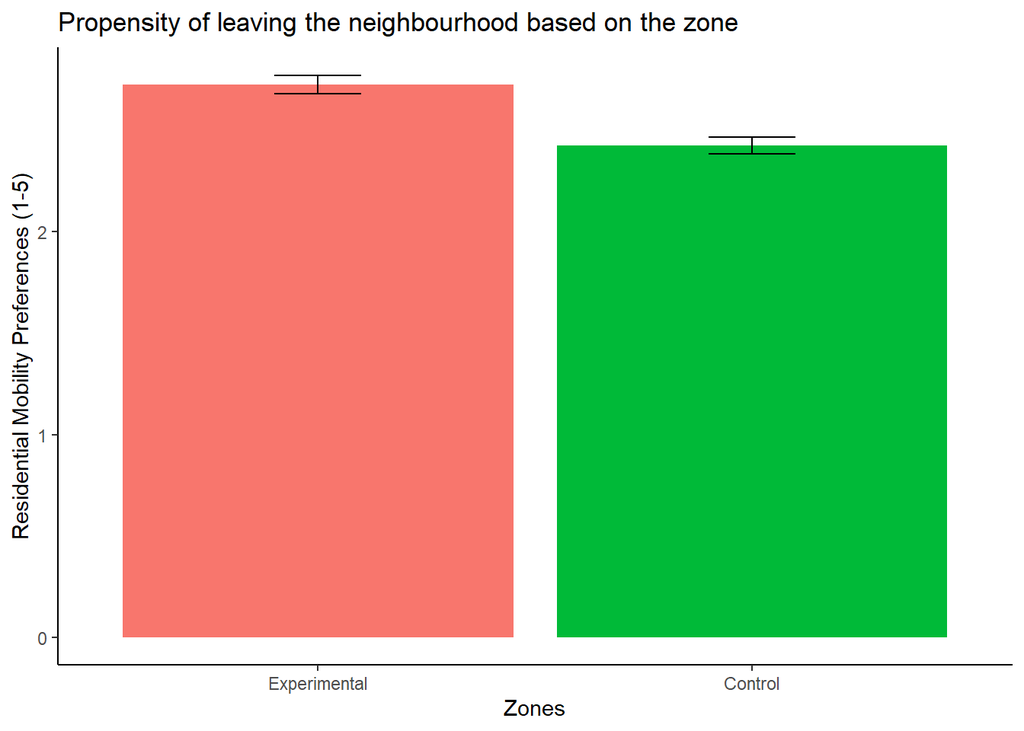

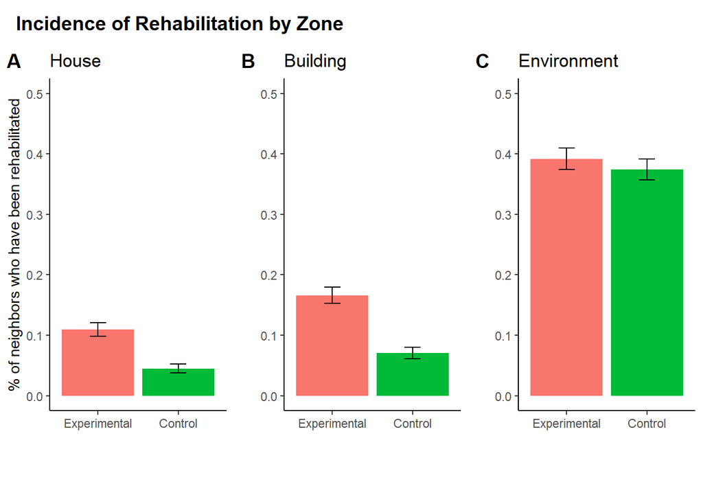

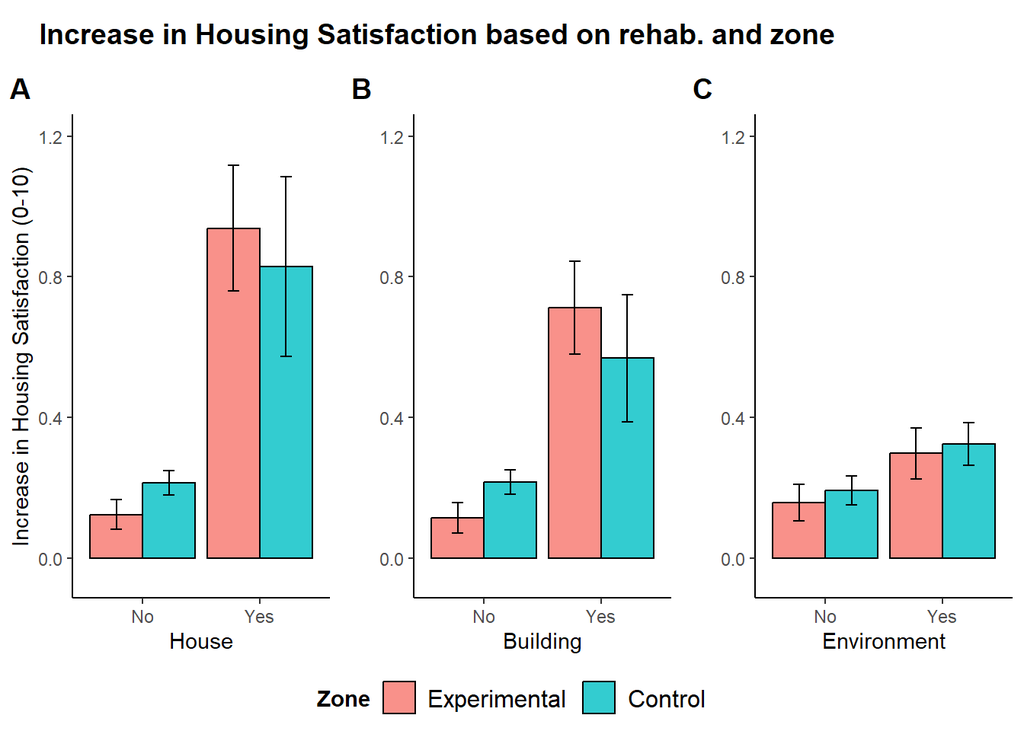

## 3. Methodology & Results

### 3.1. DiD Estimation

We have done a pseudo-DiD design in order to evaluate if the rehabilitation have an actual positive impact on housing satisfaction.

We use housing satisfaction as the mechanism through the rehabilitation affects the propensity of leaving the neighbourhood, since the rehabilitation could have not improve the households at all, and if this happens we obviously expect the effect to be 0.

We perform the DiD design with every rehabilitation variable -housing, building and environment-:

$y_{it} = \alpha + \beta_1 \cdot R_i + \beta_2 \cdot D_t + \gamma \cdot (R_i \times D_t) + \beta_3 \cdot (R_i \times Z_i) + \beta_4 \cdot C_i + \epsilon_{it}$

where: $y_{it}$ represents the outcome variable for unit $i$ at time $t$ (before or after the rehabilitation). $R_i$ is a binary treatment indicator variable, taking a value of 1 if unit $i$ is in the rehabilited group and 0 otherwise. $D_t$ is a binary indicator variable for the post-treatment period, taking a value of 1 if time $t$ is in the post-rehabilitation period and 0 otherwise. $Z_i$ is a binary indicator variable for the areas, taking a value of 1 if time $t$ is in the affected area and 0 otherwise. $C_i$ represents all the confounders taking in account to avoid bias estimation of $R_i$ and $Z_i$

**Housing**

```
##
## t test of coefficients:
##
##                                  Estimate  Std. Error t value  Pr(>|t|)
## (Intercept)                    2.04136417  0.10732410 19.0206 < 2.2e-16 ***
## hsn                            2.11665453  0.31816412  6.6527 3.135e-11 ***
## sths0                          0.70403219  0.01381367 50.9663 < 2.2e-16 ***
## problemviv                    -0.88446362  0.09564696 -9.2472 < 2.2e-16 ***
## eco                            0.02530109  0.00966283  2.6184 0.0088569 **
## support                        0.10813265  0.02370658  4.5613 5.186e-06 ***
## relvel                         0.17931295  0.13368707  1.3413 0.1798780
## age                            0.00031183  0.00119383  0.2612 0.7939479
## familyCouple without children  0.03553039  0.03652143  0.9729 0.3306603
## familyMother with children     0.02460372  0.06683479  0.3681 0.7127914
## familyFather with Children    -0.14203469  0.12675178 -1.1206 0.2625147
## familyAlone woman             -0.03848457  0.06025322 -0.6387 0.5230336
## familyAlone man               -0.17392226  0.06728764 -2.5848 0.0097684 **
## familySeveral families        -0.14135752  0.10358213 -1.3647 0.1724021
## familyOther                   -0.20041074  0.05256167 -3.8129 0.0001388 ***
## hsn:sths0                     -0.23961666  0.04399714 -5.4462 5.353e-08 ***
## hsn:exp                       -0.06600255  0.15290487 -0.4317 0.6660059
## ---
## Signif. codes:  0 '***' 0.001 '**' 0.01 '*' 0.05 '.' 0.1 ' ' 1
```

**Building**

```
##
## t test of coefficients:
##
##                                 Estimate Std. Error t value  Pr(>|t|)
## (Intercept)                    2.0190032  0.1098983 18.3716 < 2.2e-16 ***
## bld                            1.5107776  0.2683236  5.6304 1.880e-08 ***
## P0225                          0.7024986  0.0141572 49.6212 < 2.2e-16 ***
## problemviv                    -0.8795180  0.0958501 -9.1760 < 2.2e-16 ***
## eco                            0.0284777  0.0096621  2.9474 0.0032173 **
## support                        0.1193462  0.0236388  5.0487 4.580e-07 ***
## relvel                         0.2250327  0.1306570  1.7223 0.0850643 .
## age                            0.0004586  0.0012113  0.3786 0.7049998
## familyCouple without children  0.0394283  0.0366523  1.0757 0.2820873
## familyMother with children     0.0235251  0.0671416  0.3504 0.7260658
## familyFather with Children    -0.1770088  0.1281263 -1.3815 0.1671719
## familyAlone woman             -0.0062430  0.0615582 -0.1014 0.9192236
## familyAlone man               -0.1638602  0.0671285 -2.4410 0.0146760 *
## familySeveral families        -0.1241837  0.1050721 -1.1819 0.2372965
## familyOther                   -0.1749912  0.0524159 -3.3385 0.0008475 ***
## bld:sths0                     -0.1779253  0.0379774 -4.6850 2.861e-06 ***
## bld:exp                       -0.0135902  0.1148102 -0.1184 0.9057779
## ---
## Signif. codes:  0 '***' 0.001 '**' 0.01 '*' 0.05 '.' 0.1 ' ' 1
```

**Environment**

```
##
## t test of coefficients:
##
##                                  Estimate  Std. Error t value  Pr(>|t|)
## (Intercept)                    1.98884429  0.12632345 15.7441 < 2.2e-16 ***
## env                            0.98298125  0.18171568  5.4094 6.569e-08 ***
## P0225                          0.70913998  0.01702818 41.6451 < 2.2e-16 ***
## problemviv                    -0.87124796  0.09659851 -9.0193 < 2.2e-16 ***
## eco                            0.02062796  0.00969277  2.1282 0.0333631 *
## support                        0.10154927  0.02354980  4.3121 1.643e-05 ***
## relvel                         0.15825986  0.13500363  1.1723 0.2411382
## age                            0.00053694  0.00121692  0.4412 0.6590650
## familyCouple without children  0.03549619  0.03677310  0.9653 0.3344458
## familyMother with children     0.04074198  0.06865531  0.5934 0.5529174
## familyFather with Children    -0.14461460  0.13042024 -1.1088 0.2675460
## familyAlone woman             -0.02520962  0.06241819 -0.4039 0.6863136
## familyAlone man               -0.16084171  0.06725587 -2.3915 0.0168111 *
## familySeveral families        -0.09609163  0.10552396 -0.9106 0.3625356
## familyOther                   -0.19566783  0.05276681 -3.7082 0.0002107 ***
## env:sths0                     -0.10470898  0.02491324 -4.2029 2.673e-05 ***
## env:exp                       -0.16978915  0.05023743 -3.3797 0.0007302 ***
## ---
## Signif. codes:  0 '***' 0.001 '**' 0.01 '*' 0.05 '.' 0.1 ' ' 1
```

### 3.2. SEM Model

```r
indirind <- '
# measurement model
rehab =~ hsn + bld + env
# regressions
rehab ~ exp
sths ~ rehab + support + problemviv
stng ~ sths + support  + eco + problemviv
resmov ~ stng + support + eco + problemviv
'


fit <- sem(indirind, data=df)
```

**Graph of the SEM Model (only significant effects shown)**

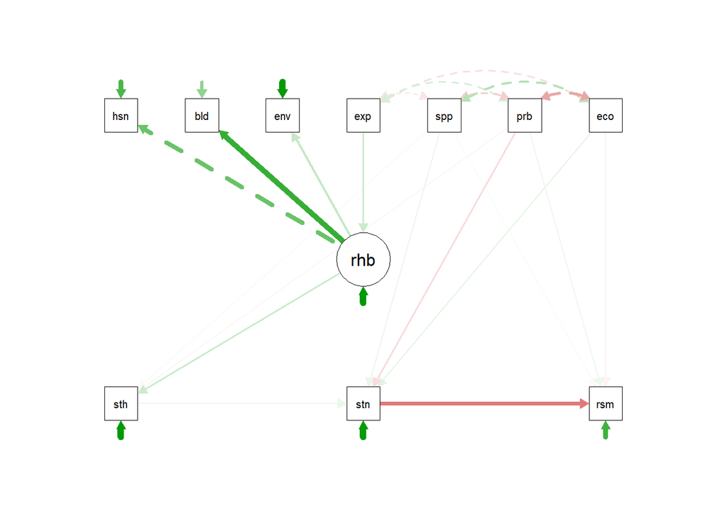

**Results of the SEM Model (only significant variables included)**

```
## lavaan 0.6.15 ended normally after 74 iterations
##
##   Estimator                                         ML
##   Optimization method                           NLMINB
##   Number of model parameters                        21
##
##   Number of observations                          5960
##
## Model Test User Model:
##
##   Test statistic                               522.777
##   Degrees of freedom                                24
##   P-value (Chi-square)                           0.000
##
## Model Test Baseline Model:
##
##   Test statistic                              4466.136
##   Degrees of freedom                                39
##   P-value                                        0.000
##
## User Model versus Baseline Model:
##
##   Comparative Fit Index (CFI)                    0.887
##   Tucker-Lewis Index (TLI)                       0.817
##
## Loglikelihood and Information Criteria:
##
##   Loglikelihood user model (H0)             -32068.368
##   Loglikelihood unrestricted model (H1)     -31806.980
##
##   Akaike (AIC)                               64178.736
##   Bayesian (BIC)                             64319.285
##   Sample-size adjusted Bayesian (SABIC)      64252.553
##
## Root Mean Square Error of Approximation:
##
##   RMSEA                                          0.059
##   90 Percent confidence interval - lower         0.055
##   90 Percent confidence interval - upper         0.064
##   P-value H_0: RMSEA <= 0.050                    0.000
```

[output cut: 32 more lines]

```
##   resmov ~
##     stng             -0.654    0.015  -43.732    0.000   -0.654   -0.497
##     support           0.048    0.019    2.526    0.012    0.048    0.029
##     eco              -0.036    0.009   -3.831    0.000   -0.036   -0.046
##     problemviv        0.392    0.070    5.591    0.000    0.392    0.066
##
## Variances:
##                    Estimate  Std.Err  z-value  P(>|z|)   Std.lv  Std.all
##    .hsn               0.048    0.002   28.757    0.000    0.048    0.680
##    .bld               0.043    0.004   11.118    0.000    0.043    0.415
##    .env               0.225    0.004   53.080    0.000    0.225    0.953
##    .sths              1.606    0.030   53.434    0.000    1.606    0.961
##    .stng              0.806    0.015   54.589    0.000    0.806    0.943
##    .resmov            1.079    0.020   54.589    0.000    1.079    0.730
##    .rehab             0.022    0.002   13.345    0.000    0.963    0.963
```

**Comparison of effects: Income and rehabilitation**

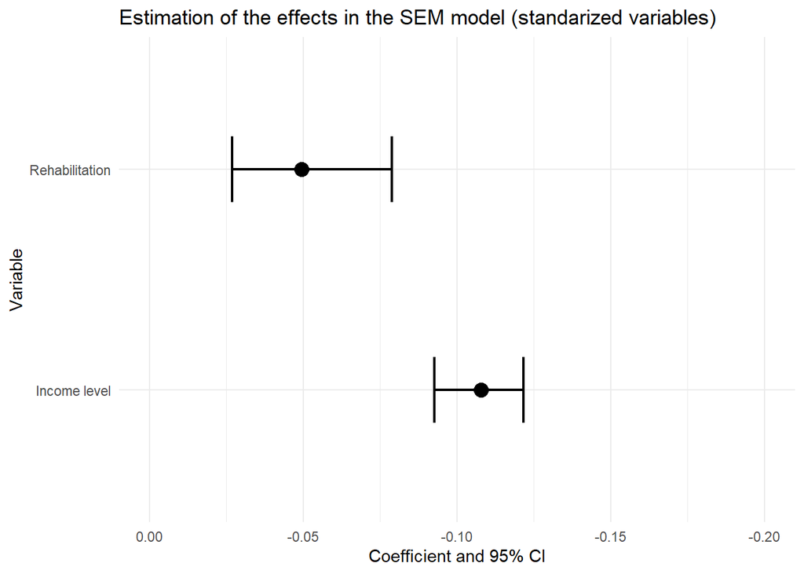

### 3.3. Final Causal DAG

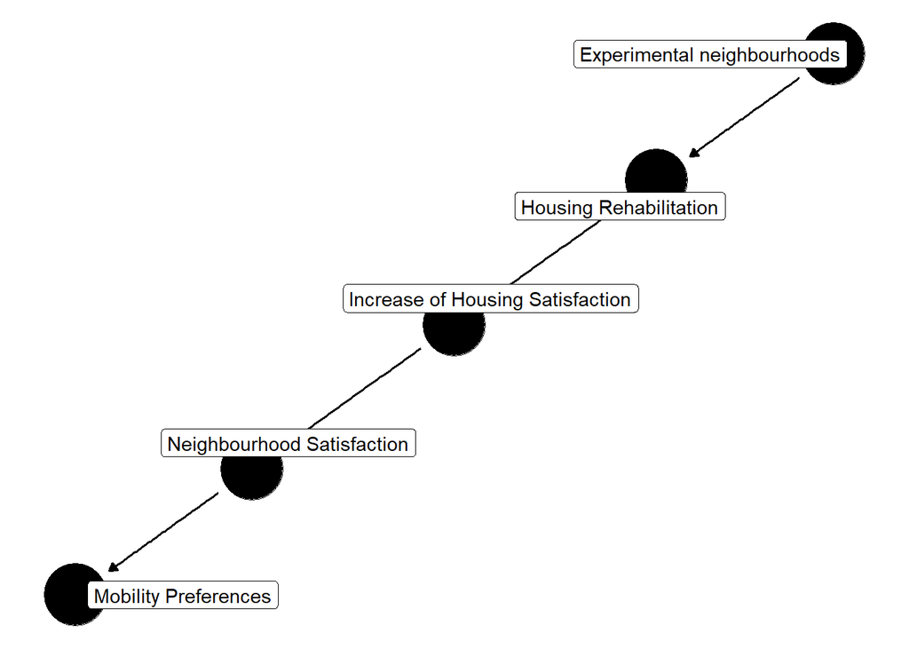

## 4. Summary Statistics

Summary Statistics

| Variable | N | Percent |
| --- | --- | --- |
| TIPO_ZONA | 5960 |  |
| … Experimental | 2968 | 50% |
| … Control | 2992 | 50% |
| … Other | 0 | 0% |
| hsn | 5960 |  |
| … No | 5502 | 92% |
| … Yes | 458 | 8% |
| bld | 5960 |  |
| … No | 5256 | 88% |
| … Yes | 704 | 12% |
| env | 5960 |  |
| … No | 3677 | 62% |
| … Yes | 2283 | 38% |
| family | 5960 |  |
| … Couple with children | 2659 | 45% |
| … Couple without children | 1293 | 22% |
| … Mother with children | 424 | 7% |
| … Father with Children | 60 | 1% |
| … Alone woman | 386 | 6% |
| … Alone man | 364 | 6% |
| … Several families | 257 | 4% |
| … Other | 517 | 9% |

Summary Statistics

| Variable | N | Mean | Std. Dev. | Min | Pctl. 25 | Pctl. 75 | Max |
| --- | --- | --- | --- | --- | --- | --- | --- |
| eco | 5960 | 3.2 | 1.6 | 1 | 2 | 3 | 9 |
| support | 5960 | 0.66 | 0.74 | -1.6 | 0.18 | 1.1 | 3.2 |
| stng | 5960 | 3.7 | 0.92 | 1 | 4 | 4 | 5 |
| sths | 5960 | 0.23 | 1.3 | -10 | 0 | 0 | 10 |
| problemviv | 5960 | 0.1 | 0.21 | 0 | 0 | 0 | 1 |
| resmov | 5960 | 2.6 | 1.2 | 1 | 2 | 4 | 5 |
| relvel | 5960 | 0.051 | 0.13 | 0 | 0 | 0 | 1 |
| age | 5960 | 29 | 12 | 0 | 25 | 33 | 85 |